# Homework 3

Yu-Jen Lin

#### b04b01036@ntu.edu.tw

#### ——————————————————————————————————————————————————–

#### Set working directory

```r
setwd("~/R")
```

#### Read enviANDdensity.csv into R

```r
enviANDdensity <- read.csv(file="~/R/enviANDdensity.csv", header=TRUE)
```

Because we only need the data in “FishDensity..ind..1000m3.” and “CopepodDensity.ind..m3.”, I take these two columns out and set as “FishDensity” and “CopepodDensity” separately.

```r
FishDensity <- enviANDdensity$FishDensity..ind..1000m3.
CopepodDensity <- enviANDdensity$CopepodDensity.ind..m3.
```

###### ————————————————————————————————————————————————————————————————————————————-

#### 1. Compute the mean and SE(mean) for the fish and copepod densities (assuming all data points are independent) respectively, using both normal theory and non-parametric bootstrap. Plot the histogram of bootstrapped means with bootstrap 1000 times. (Normal theory simply means using the standard formula to estimate SE.)

#### mean and SE(mean)

```r
FishDensity.mean <- mean(FishDensity)
FishDensity.mean
```

```
## [1] 322.4516
```

```r
FishDensity.SE <- var(FishDensity)^0.5/length(FishDensity)^0.5
FishDensity.SE
```

```
## [1] 61.23107
```

```r
CopepodDensity.mean <- mean(CopepodDensity)
CopepodDensity.mean
```

```
## [1] 1972.374
```

```r
CopepodDensity.SE <- var(CopepodDensity)^0.5/length(CopepodDensity)^0.5
CopepodDensity.SE
```

```
## [1] 342.5549
```

#### non-parametric bootstrap

1. FishDensity bootstrap means

```r
FishDensity.bootstrap.means <- c() # set a vector to put the following sampling results
for (i in 1:1000) {
random <- ceiling(runif(34, min=0, max=34))
bootstrap.i <- FishDensity[random] # single sampling result
FishDensity.bootstrap.means[i] <- mean(bootstrap.i) # put every mean of every single result into the vector I've created
}
append(FishDensity.bootstrap.means, FishDensity.mean) # add the mean calculated by normal theory (total:1001)
```

[output not shown]

[output cut: 152 more lines]

```r
FishDensity.bootstrap.means.mean <- mean(FishDensity.bootstrap.means) # mean of bootstrap means
FishDensity.bootstrap.means.mean
```

```
## [1] 325.4912
```

```r
FishDensity.bootstrap.means.SE <- var(FishDensity.bootstrap.means)^0.5/length(FishDensity.bootstrap.means)^0.5
FishDensity.bootstrap.means.SE
```

```
## [1] 2.000397
```

2. CopepodDensity bootstrap means

```r
CopepodDensity.bootstrap.means <- c() # set a vector to put the following sampling results
for (i in 1:1000) {
random <- ceiling(runif(34, min=0, max=34))
bootstrap.i <- CopepodDensity[random] # single sampling result
CopepodDensity.bootstrap.means[i] <- mean(bootstrap.i) # put every mean of every single result into the vector I've created
}
append(CopepodDensity.bootstrap.means, CopepodDensity.mean) # add the mean calculated by normal theory (total:1001)
```

[output not shown]

[output cut: 128 more lines]

```r
CopepodDensity.bootstrap.means.mean <- mean(CopepodDensity.bootstrap.means) # mean of bootstrap means
CopepodDensity.bootstrap.means.mean
```

```
## [1] 1982.823
```

```r
CopepodDensity.bootstrap.means.SE <- var(CopepodDensity.bootstrap.means)^0.5/length(CopepodDensity.bootstrap.means)^0.5
CopepodDensity.bootstrap.means.SE
```

```
## [1] 10.47058
```

#### plot the histogram

1. FishDensity means by Bootstrap or Normal Theory

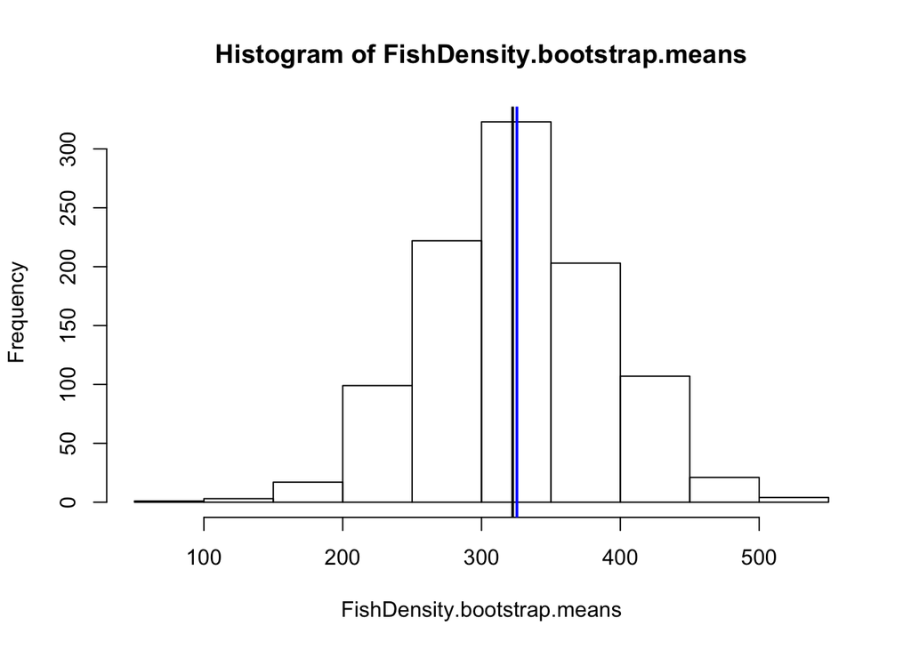

```r
hist(FishDensity.bootstrap.means)
abline(v = FishDensity.mean, col = "black", lwd = 2)
abline(v = FishDensity.bootstrap.means.mean, col = "blue", lwd = 2)
```

2. CopepodDensity means by Bootstrap or Normal Theory

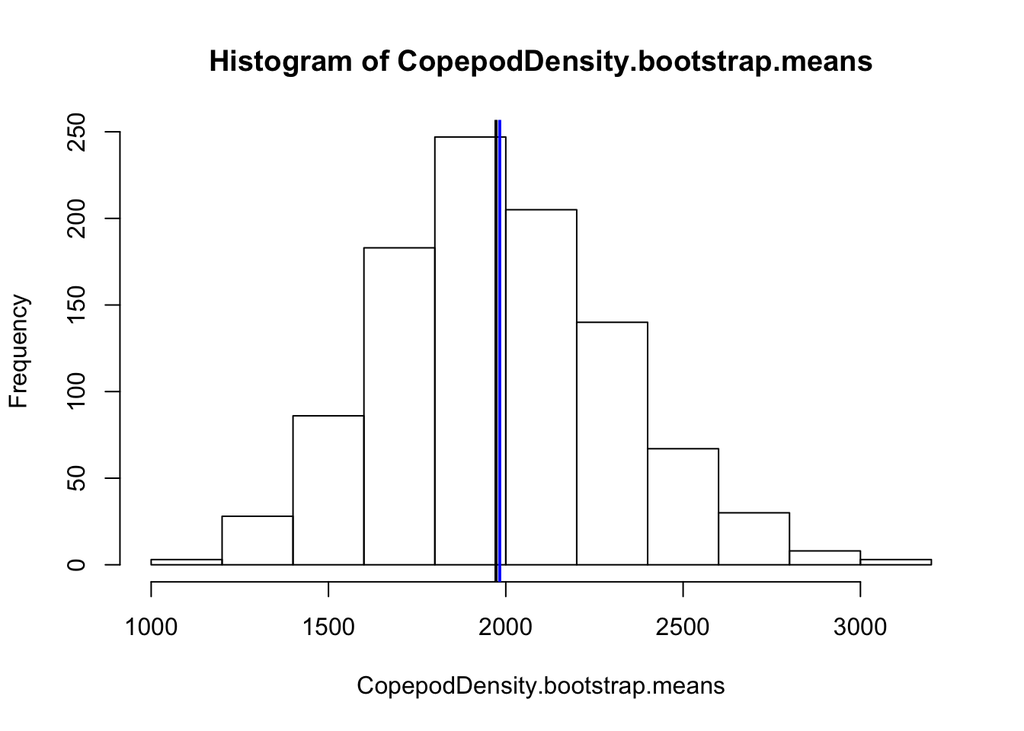

```r
hist(CopepodDensity.bootstrap.means)
abline(v = CopepodDensity.mean, col = "black", lwd = 2)
abline(v = CopepodDensity.bootstrap.means.mean, col = "blue", lwd = 2)
```

###### ————————————————————————————————————————————————————————————————————————————-

#### 2. Compute the median and bootstrapped SE(median) for the fish and copepod densities. Plot the histogram of bootstrapped medians with bootstrap 1000 times.

#### median

```r
FishDensity.median <- median(FishDensity)
FishDensity.median
```

```
## [1] 142.9266
```

```r
CopepodDensity.median <- median(CopepodDensity)
CopepodDensity.median
```

```
## [1] 1352.5
```

#### non-parametric bootstrap

1. FishDensity bootstrap medians

```r
FishDensity.bootstrap.medians <- c() # set a vector to put the following sampling results
for (i in 1:1000) {
random <- ceiling(runif(34, min=0, max=34))
bootstrap.i <- FishDensity[random] # single sampling result
FishDensity.bootstrap.medians[i] <- median(bootstrap.i) # put every median of every single result into the vector I've created
}
append(FishDensity.bootstrap.medians, FishDensity.median) # add the median calculated by normal theory (total:1001)
```

[output not shown]

[output cut: 152 more lines]

```r
FishDensity.bootstrap.medians.median <- median(FishDensity.bootstrap.medians) # median of bootstrap medians
FishDensity.bootstrap.medians.median
```

```
## [1] 142.9266
```

```r
FishDensity.bootstrap.medians.SE <- var(FishDensity.bootstrap.medians)^0.5/length(FishDensity.bootstrap.medians)^0.5
FishDensity.bootstrap.medians.SE
```

```
## [1] 3.115299
```

2. CopepodDensity bootstrap medians

```r
CopepodDensity.bootstrap.medians <- c() # set a vector to put the following sampling results
for (i in 1:1000) {
random <- ceiling(runif(34, min=0, max=34))
bootstrap.i <- CopepodDensity[random] # single sampling result
CopepodDensity.bootstrap.medians[i] <- median(bootstrap.i) # put every median of every single result into the vector I've created
}
append(CopepodDensity.bootstrap.medians, CopepodDensity.median) # add the median calculated by normal theory (total:1001)
```

[output not shown]

[output cut: 111 more lines]

```r
CopepodDensity.bootstrap.medians.median <- median(CopepodDensity.bootstrap.medians) # median of bootstrap medians
CopepodDensity.bootstrap.medians.median
```

```
## [1] 1352.5
```

```r
CopepodDensity.bootstrap.medians.SE <- var(CopepodDensity.bootstrap.medians)^0.5/length(CopepodDensity.bootstrap.medians)^0.5
CopepodDensity.bootstrap.medians.SE
```

```
## [1] 6.727205
```

#### plot the histogram

1. FishDensity medians by Bootstrap or Normal Theory

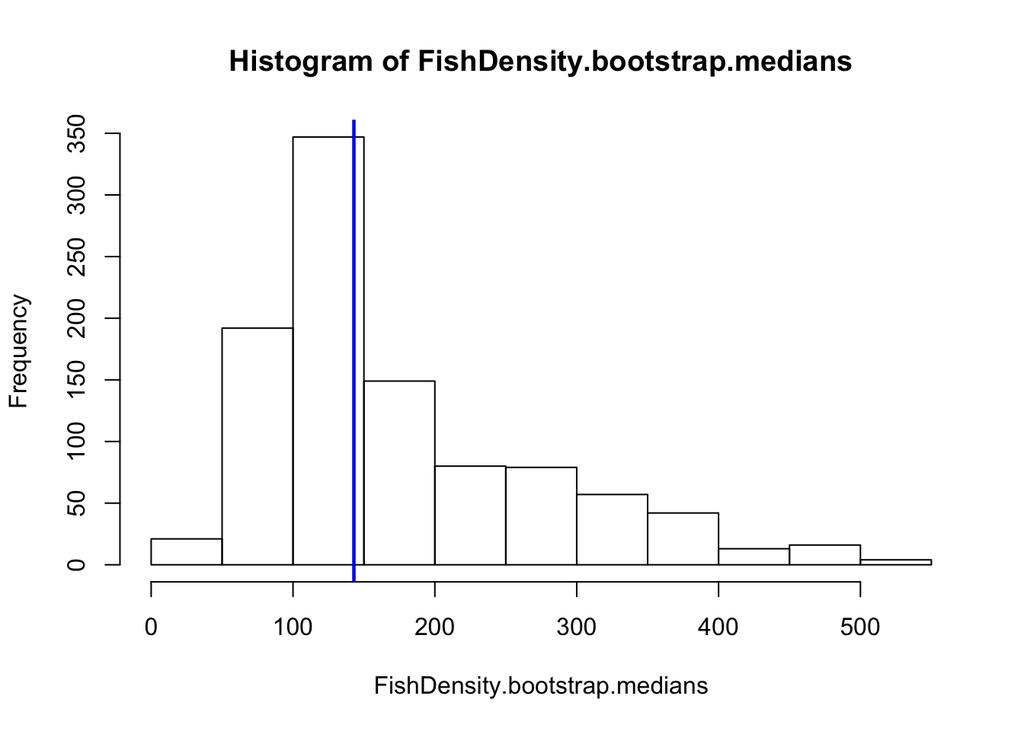

```r
hist(FishDensity.bootstrap.medians)
abline(v = FishDensity.median, col = "black", lwd = 2)
abline(v = FishDensity.bootstrap.medians.median, col = "blue", lwd = 2)
```

2. CopepodDensity medians by Bootstrap or Normal Theory

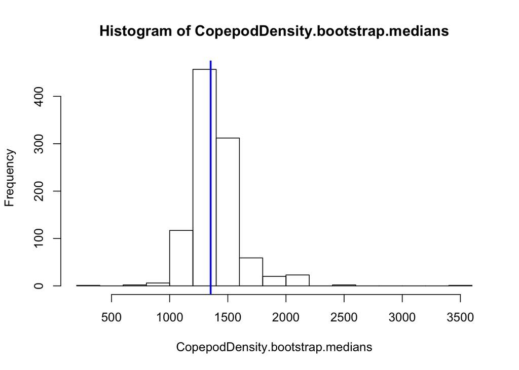

```r
hist(CopepodDensity.bootstrap.medians)
abline(v = CopepodDensity.median, col = "black", lwd = 2)
abline(v = CopepodDensity.bootstrap.medians.median, col = "blue", lwd = 2)
```

###### ————————————————————————————————————————————————————————————————————————————-

#### 1. & 2. Compare normal theory and bootstrap

Compare the median of bootstrap medians with the original sampling median. They are almost the same number, only that through doing bootstrap, our median of bootstrap medians is closer to the original population median.

```r
Fish.normal <- c(FishDensity.mean, FishDensity.SE, FishDensity.median, "-")
Fish.bootstrap <- c(FishDensity.bootstrap.means.mean, FishDensity.bootstrap.means.SE, FishDensity.bootstrap.medians.median,FishDensity.bootstrap.medians.SE)
Fish <- data.frame(Fish.normal,Fish.bootstrap)
rownames(Fish) <- c("mean", "SE(mean)", "median", "SE(median)" )
Fish
```

```
##                 Fish.normal Fish.bootstrap
## mean       322.451633316735     325.491163
## SE(mean)   61.2310707375046       2.000397
## median          142.9265688     142.926569
## SE(median)                -       3.115299
```

```r
Copepod.normal <- c(CopepodDensity.mean, CopepodDensity.SE, CopepodDensity.median, "-")
Copepod.bootstrap <- c(CopepodDensity.bootstrap.means.mean, CopepodDensity.bootstrap.means.SE, CopepodDensity.bootstrap.medians.median,CopepodDensity.bootstrap.medians.SE)
Copepod <- data.frame(Copepod.normal,Copepod.bootstrap)
rownames(Copepod) <- c("mean", "SE(mean)", "median", "SE(median)" )
Copepod
```

```
##              Copepod.normal Copepod.bootstrap
## mean       1972.37411764706       1982.822649
## SE(mean)   342.554903173053         10.470581
## median               1352.5       1352.500000
## SE(median)                -          6.727205
```

###### ————————————————————————————————————————————————————————————————————————————-

#### 3. Plot fish (dependent) v.s. copepod (independent) and the regression line. Compute the regression coefficients for

#### fish = β0+β1*copepod and bootstrapped SE(β0) and SE(β1). Plot the histogram of bootstrapped β0 and β1 with bootstrap 1000 times.

#### Compute the regression coefficients for

#### fish(y) = β0 + β1 * copepod(x).

Dimension of y -> (n,1) Dimension of β0 -> (n,1) Dimension of β1 -> (k+1,1) Dimension of X -> (n,k+1)

```r
n <- length(FishDensity)
k <- 1

y  <- matrix(FishDensity, nrow=n, ncol=1, byrow = TRUE) # put the original sample into y
x  <- matrix(c(rep(1, times=n),CopepodDensity), nrow=n, ncol=k+1, byrow = FALSE)  # put the original sample into x

β1 <- solve(t(x) %*% x) %*% t(x) %*% y
β1
```

```
##            [,1]
## [1,] 93.0646559
## [2,]  0.1162999
```

```r
β0 <- y - x %*% β1  # fish(y) = β0 + β1 * copepod(x)
```

Thus, through β1, I found the intercept of the regression line is 93.0647 and the slope of the regression line is 0.1163. y = 93.0647 + 0.1163*x

#### Plot fish (dependent) v.s. copepod (independent) and the regression line.

I plot the regression line I just computed in below. (blue) y = 93.0647 + 0.1163*x

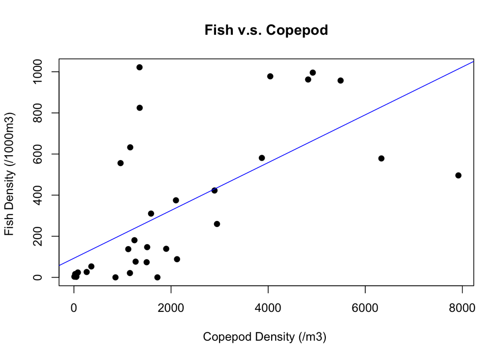

```r
plot(CopepodDensity, FishDensity, main="Fish v.s. Copepod",
    xlab="Copepod Density (/m3) ", ylab="Fish Density (/1000m3) ", pch=19)
abline(a=93.0647, b=0.1163, col="blue") # regression line (y~x) # the regression line I computed in previous step, a=intercept b=slope
```

#### bootstrapped SE(β0) and SE(β1).

```r
# set vectors to put the following sampling results
bootstrap.β0 <- c()
bootstrap.β1 <- c()

# set starting points
n.bt <- length(FishDensity)
k.bt <- 10
x.bt  <- matrix(c(rep(1, times=n.bt)), nrow=n.bt, ncol=1, byrow = FALSE)

# bootstrap
for (i in 1:10) {
random <- ceiling(runif(34, min=0, max=34))
bootstrap.Fish.i <- FishDensity[random] # single sampling result
bootstrap.Copepod.i <- CopepodDensity[random] # single sampling result

y.bt  <- matrix(bootstrap.Fish.i, nrow=n.bt, ncol=1, byrow = FALSE) # put the bootstrap sample into y.bt
x.bt  <- cbind(x.bt, bootstrap.Copepod.i) # combine the new column into the x.bt

β1.bt <- solve(t(x.bt) %*% x.bt) %*% t(x.bt) %*% y.bt
bootstrap.β0[i] <- β1.bt[1] # intercept
bootstrap.β1[i] <- β1.bt[2] # slope
}

append(bootstrap.β0, β1[1]) # add the SE(β0) calculated by normal theory (total:1001)
```

```
##  [1]   55.41677  130.10806  180.30558   12.68648  370.17868  221.46558
##  [7]  -11.14685 -108.48559   77.37593  304.26011   93.06466
```

```r
append(bootstrap.β1, β1[2]) # add the SE(β1) calculated by normal theory (total:1001)
```

```
##  [1]  0.125669897  0.015127386 -0.042116590  0.008666600 -0.023072932
##  [6] -0.030138013 -0.016469454 -0.004320809  0.047909872 -0.044227821
## [11]  0.116299933
```

```r
bootstrap.β0.SE <- var(bootstrap.β0)^0.5/length(bootstrap.β0)^0.5
bootstrap.β0.SE
```

```
## [1] 46.83079
```

```r
bootstrap.β1.SE <- var(bootstrap.β1)^0.5/length(bootstrap.β1)^0.5
bootstrap.β1.SE
```

```
## [1] 0.01623289
```

bootstrapped β0

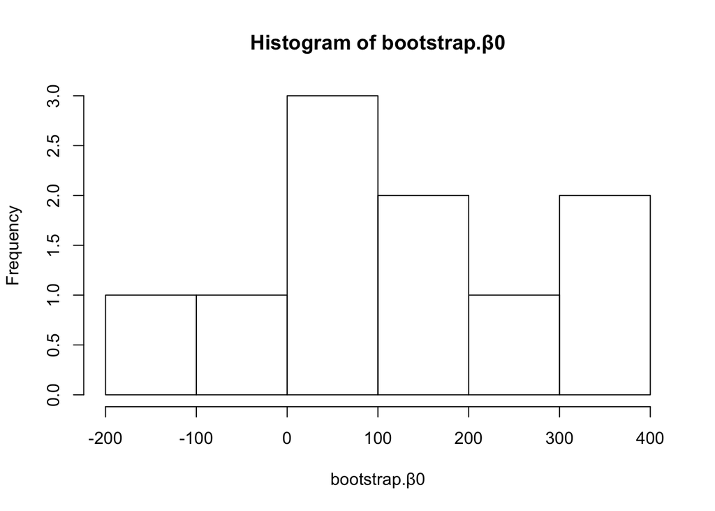

```r
hist(bootstrap.β0)
```

[figure not shown]

```r
hist(bootstrap.β0)
```